# 红葡萄酒质量探索

郑义铭

2019年05月05日

# 加载必要的库、红酒数据集

```
## [1] "C"
```

## 观察数据集的概略

先观察一下数据框的概略

```
##        X          fixed.acidity   volatile.acidity  citric.acid
##  Min.   :   1.0   Min.   : 4.60   Min.   :0.1200   Min.   :0.000
##  1st Qu.: 400.5   1st Qu.: 7.10   1st Qu.:0.3900   1st Qu.:0.090
##  Median : 800.0   Median : 7.90   Median :0.5200   Median :0.260
##  Mean   : 800.0   Mean   : 8.32   Mean   :0.5278   Mean   :0.271
##  3rd Qu.:1199.5   3rd Qu.: 9.20   3rd Qu.:0.6400   3rd Qu.:0.420
##  Max.   :1599.0   Max.   :15.90   Max.   :1.5800   Max.   :1.000
##  residual.sugar     chlorides       free.sulfur.dioxide
##  Min.   : 0.900   Min.   :0.01200   Min.   : 1.00
##  1st Qu.: 1.900   1st Qu.:0.07000   1st Qu.: 7.00
##  Median : 2.200   Median :0.07900   Median :14.00
##  Mean   : 2.539   Mean   :0.08747   Mean   :15.87
##  3rd Qu.: 2.600   3rd Qu.:0.09000   3rd Qu.:21.00
##  Max.   :15.500   Max.   :0.61100   Max.   :72.00
##  total.sulfur.dioxide    density             pH          sulphates
##  Min.   :  6.00       Min.   :0.9901   Min.   :2.740   Min.   :0.3300
##  1st Qu.: 22.00       1st Qu.:0.9956   1st Qu.:3.210   1st Qu.:0.5500
##  Median : 38.00       Median :0.9968   Median :3.310   Median :0.6200
##  Mean   : 46.47       Mean   :0.9967   Mean   :3.311   Mean   :0.6581
##  3rd Qu.: 62.00       3rd Qu.:0.9978   3rd Qu.:3.400   3rd Qu.:0.7300
##  Max.   :289.00       Max.   :1.0037   Max.   :4.010   Max.   :2.0000
##     alcohol         quality
##  Min.   : 8.40   Min.   :3.000
##  1st Qu.: 9.50   1st Qu.:5.000
##  Median :10.20   Median :6.000
##  Mean   :10.42   Mean   :5.636
##  3rd Qu.:11.10   3rd Qu.:6.000
##  Max.   :14.90   Max.   :8.000
```

```
## 'data.frame':    1599 obs. of  13 variables:
##  $ X                   : int  1 2 3 4 5 6 7 8 9 10 ...
##  $ fixed.acidity       : num  7.4 7.8 7.8 11.2 7.4 7.4 7.9 7.3 7.8 7.5 ...
##  $ volatile.acidity    : num  0.7 0.88 0.76 0.28 0.7 0.66 0.6 0.65 0.58 0.5 ...
##  $ citric.acid         : num  0 0 0.04 0.56 0 0 0.06 0 0.02 0.36 ...
##  $ residual.sugar      : num  1.9 2.6 2.3 1.9 1.9 1.8 1.6 1.2 2 6.1 ...
##  $ chlorides           : num  0.076 0.098 0.092 0.075 0.076 0.075 0.069 0.065 0.073 0.071 ...
##  $ free.sulfur.dioxide : num  11 25 15 17 11 13 15 15 9 17 ...
##  $ total.sulfur.dioxide: num  34 67 54 60 34 40 59 21 18 102 ...
##  $ density             : num  0.998 0.997 0.997 0.998 0.998 ...
##  $ pH                  : num  3.51 3.2 3.26 3.16 3.51 3.51 3.3 3.39 3.36 3.35 ...
##  $ sulphates           : num  0.56 0.68 0.65 0.58 0.56 0.56 0.46 0.47 0.57 0.8 ...
##  $ alcohol             : num  9.4 9.8 9.8 9.8 9.4 9.4 9.4 10 9.5 10.5 ...
##  $ quality             : int  5 5 5 6 5 5 5 7 7 5 ...
```

```
##  [1] "X"                    "fixed.acidity"        "volatile.acidity"
##  [4] "citric.acid"          "residual.sugar"       "chlorides"
##  [7] "free.sulfur.dioxide"  "total.sulfur.dioxide" "density"
## [10] "pH"                   "sulphates"            "alcohol"
## [13] "quality"
```

## 发现quality和X的数据类型与其他的变量不同，他们都为int，预览一下这两个变量

因为X共有1599个，又都是整数，所以推测X是观测值的唯一性标志就是id的意思 而quality 为评分，也都是整数，所以可以把这两个变量的类型都转化成facotr比较合适

```
##    Min. 1st Qu.  Median    Mean 3rd Qu.    Max.
##     1.0   400.5   800.0   800.0  1199.5  1599.0
```

```
##
##   3   4   5   6   7   8
##  10  53 681 638 199  18
```

```
##    Min. 1st Qu.  Median    Mean 3rd Qu.    Max.
##   3.000   5.000   6.000   5.636   6.000   8.000
```

## 理解各个字段的含义，并且绘制ggpair矩阵图

X 应该是id fixed.acidity 固定酸 volatile.acidity 挥发性酸 citric.acid 柠檬酸 residual.sugar 残留糖 chlorides 氯化物 free.sulfur.dioxide 游离二氧化硫 total.sulfur.dioxide 合计二氧化硫 density 密度，浓度，稠度 pH 酸碱度的指标 sulphates 硫酸盐 alcohol 酒精 quality 品质

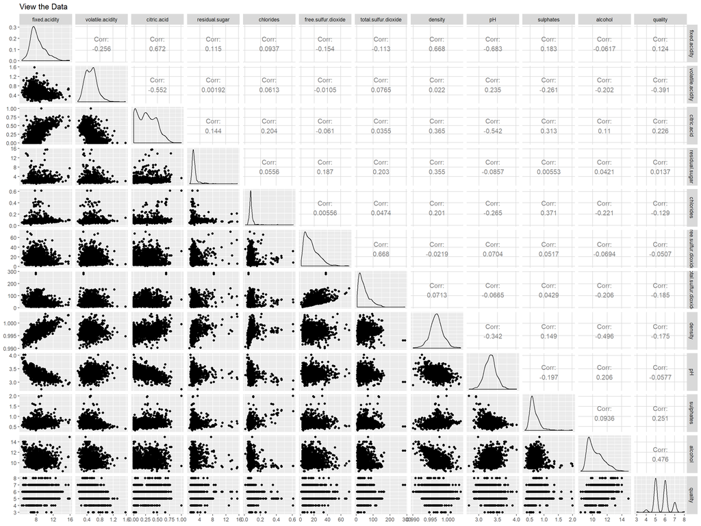

由上图可以看出，相关性很强的两个变量有下面这些，待会做多变量分析的时候需要注不要 互相干扰，影响结果。因为总共有13个变量，还是比较多的， 我们从中抽取一些可能影响 比较大的变量来进行分析，分别是： 1.residual.sugar 残留糖 2.chlorides 氯化物 3. free.sulfur.dioxide 游离二氧化硫 4.total.sulfur.dioxide 合计二氧化硫 5.volatile.acidity 挥发性酸 6.sulphates 硫酸盐 7.density 密度，浓度，稠度 8.pH 9.fixed.acidity 固定酸 10.citric.acid 柠檬酸 12.quality 品质 11.alcohol 酒精 12.quality 品质

## 改变quality和x的数据类型

```
## 'data.frame':    1599 obs. of  13 variables:
##  $ X                   : Factor w/ 1599 levels "1","2","3","4",..: 1 2 3 4 5 6 7 8 9 10 ...
##  $ fixed.acidity       : num  7.4 7.8 7.8 11.2 7.4 7.4 7.9 7.3 7.8 7.5 ...
##  $ volatile.acidity    : num  0.7 0.88 0.76 0.28 0.7 0.66 0.6 0.65 0.58 0.5 ...
##  $ citric.acid         : num  0 0 0.04 0.56 0 0 0.06 0 0.02 0.36 ...
##  $ residual.sugar      : num  1.9 2.6 2.3 1.9 1.9 1.8 1.6 1.2 2 6.1 ...
##  $ chlorides           : num  0.076 0.098 0.092 0.075 0.076 0.075 0.069 0.065 0.073 0.071 ...
##  $ free.sulfur.dioxide : num  11 25 15 17 11 13 15 15 9 17 ...
##  $ total.sulfur.dioxide: num  34 67 54 60 34 40 59 21 18 102 ...
##  $ density             : num  0.998 0.997 0.997 0.998 0.998 ...
##  $ pH                  : num  3.51 3.2 3.26 3.16 3.51 3.51 3.3 3.39 3.36 3.35 ...
##  $ sulphates           : num  0.56 0.68 0.65 0.58 0.56 0.56 0.46 0.47 0.57 0.8 ...
##  $ alcohol             : num  9.4 9.8 9.8 9.8 9.4 9.4 9.4 10 9.5 10.5 ...
##  $ quality             : Factor w/ 6 levels "3","4","5","6",..: 3 3 3 4 3 3 3 5 5 3 ...
```

# 单变量分析

下面开始单变量的分析，刚一映入眼帘的时候，个人对chlorides（氯化物） 和free.sulfur.dioxide（游离二氧化硫）和total.sulfur.dioxide (合计二氧化硫)比较感兴趣，因为氯化物一般让我想到食盐，或者是无味道的物质，然后二 氧化硫，这种大气主要污染物之一，也对红酒品质有影响吗？于是我们来观察一下

## 1.chlorides（氯化物）

我们先对chlorides（氯化物）进行探索

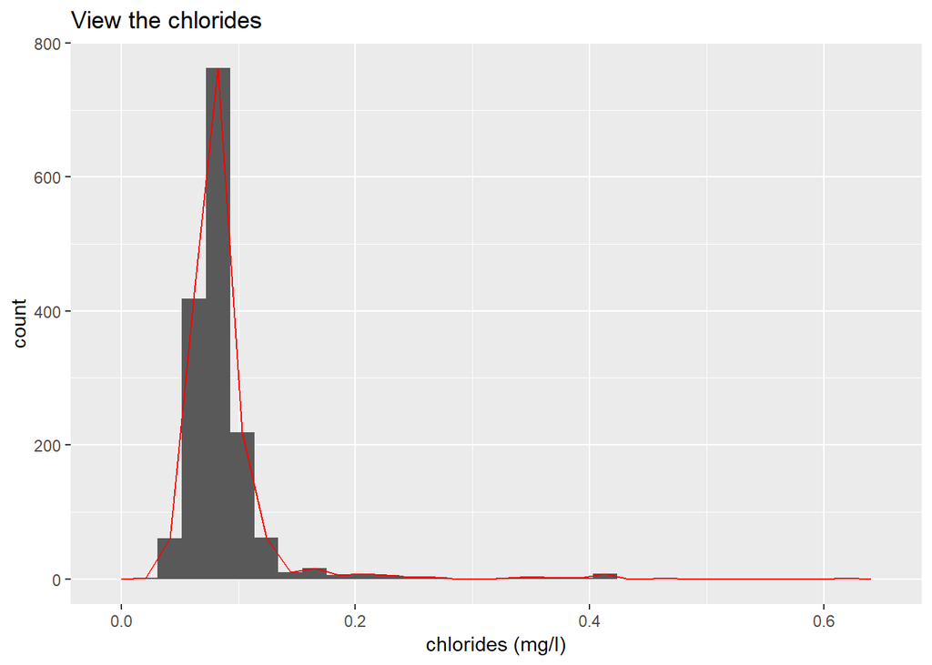

这样调整以后分布比较像正太分布

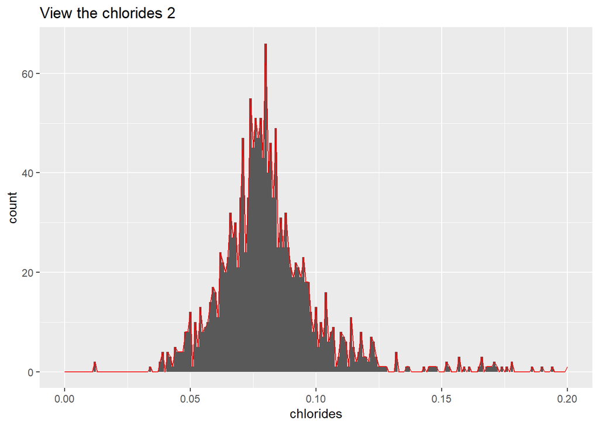

## 2.free.sulfur.dioxide

free.sulfur.dioxide 和 total.sulfur.dioxide 这两个变量之间根据上图ggpair中相关性 大小可知道为0.668 的强相关关系由下图调整过的图形看（第二个图），除了第7的位置有 一个比较高的峰值，然后整体比较均衡

可以看出主要分布在0到20之间这样，然后我们调整x轴截距为0到20

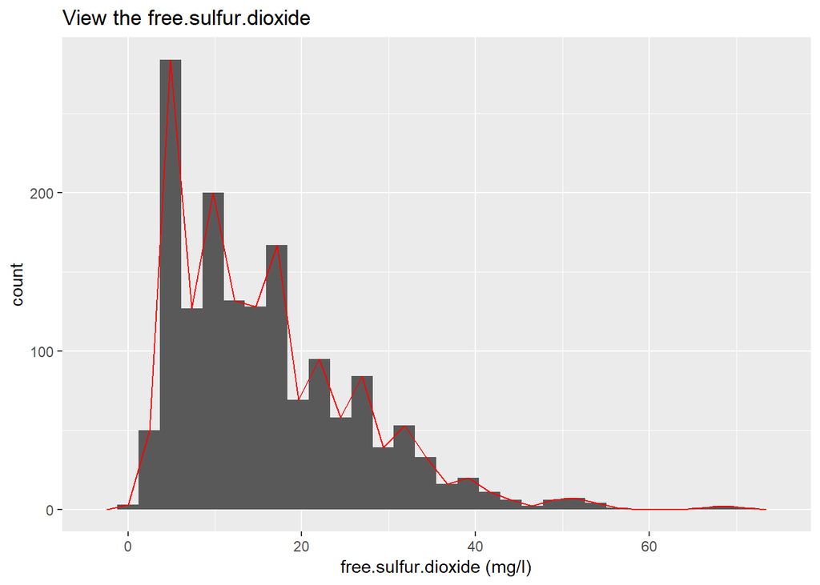

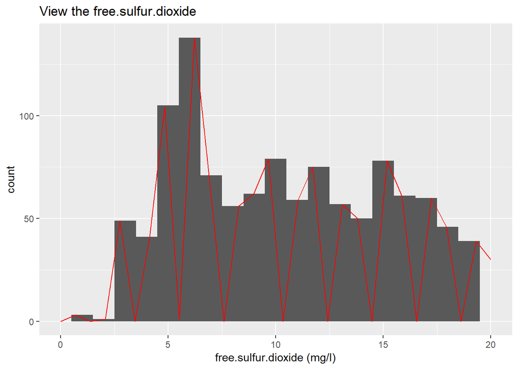

```
## [1] 72
```

## 3.total.sulfur.dioxide

然后经过查阅资料，才发现原来红酒中加入二氧化硫是为了创造酸性环境抑制别的酵母菌外 的菌落的生长作用的，所以一般160毫克/升。然后整体比较均衡，而在by函数中的输出中看 均值和中位数在不同品质中的差异同样也不是很大，所以再根据查询到用途，猜测这个量和 品质可能没那么多的关系，不过溶于红酒中的量都需要达到合格的标准。 参考 https://www.thekitchn.com/the-truth-about-sulfites-in-wine-myths-of-red-wine-headaches-100878

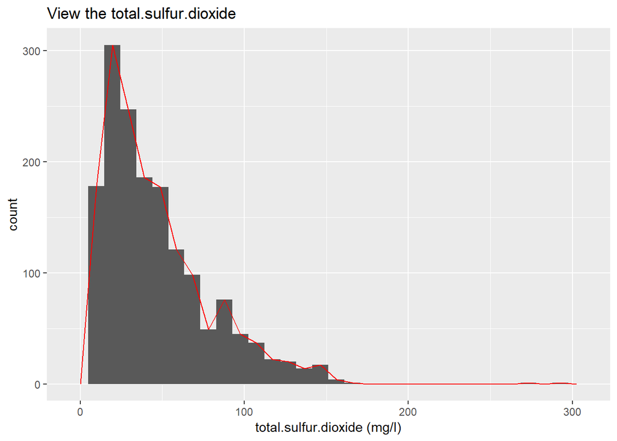

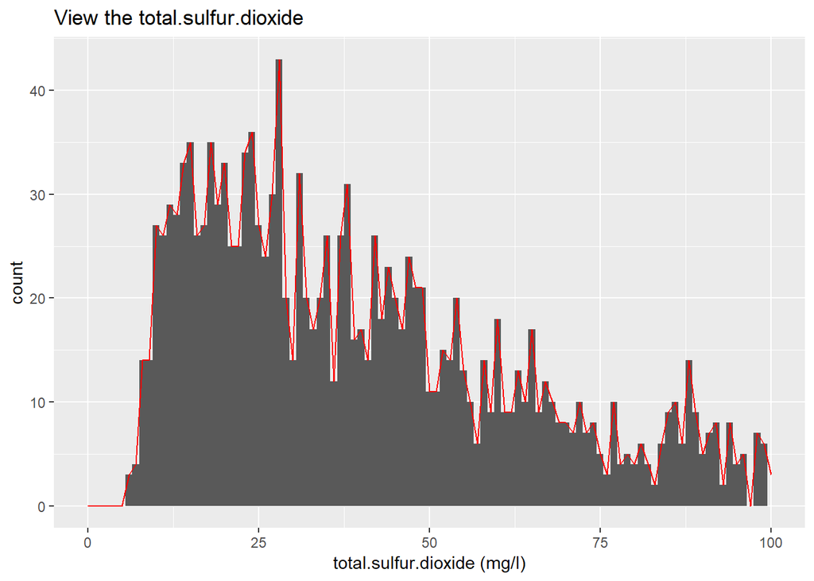

[output not shown]

## 4.sulphates 硫酸盐

经过搜索资料发现，葡萄酒中的亚硫酸盐一般来自于自然产生或者是人工天机。然后推测人 工添加的部分应该很大一部分是和加入二氧化硫气体溶于红酒里面后的量有关。

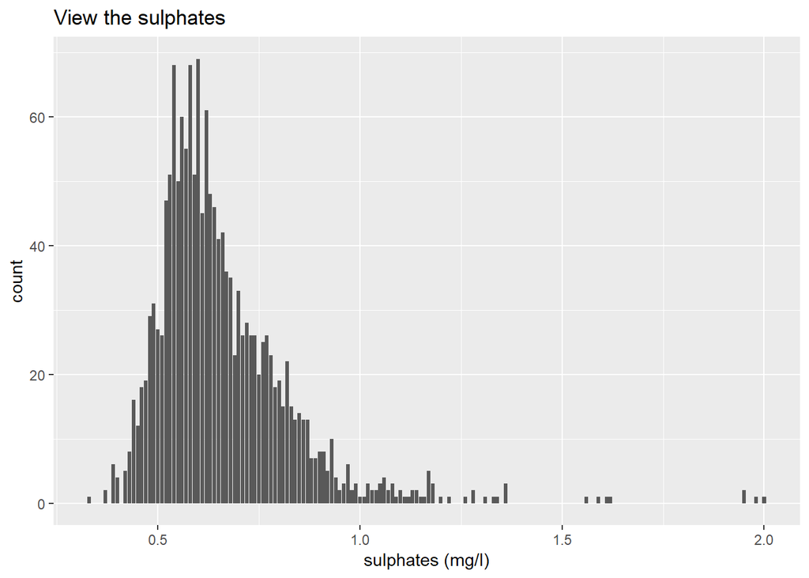

## 5.residual.sugar (残留糖)

查看残留糖的数据分布,并且调整到合适组距

粗略观察按质量分组的统计数据，看均值和中位数在各个不同品质的酒中残留糖浓度好像 区别不大 ，同理，具体可视化放在后面双边量分析

一般品尝葡萄酒的话好像都只有一点点的甜，那我们来分析一下残留糖 下图可以看到残留糖一般在1.9到2.6之间,发现主要的的区间内还是属于单峰的形状，往右边还是挺多异常值的。而且糖的含量普遍都是比较少的，所以红酒一般不太甜。

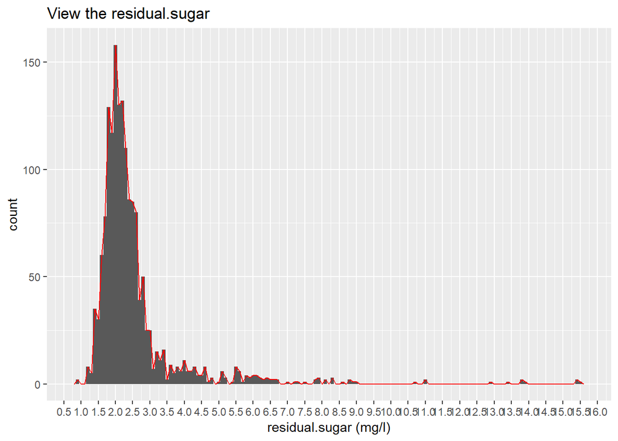

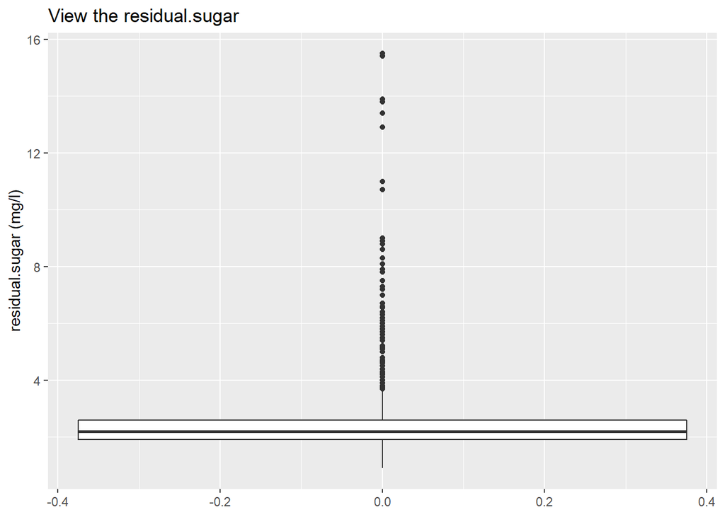

```
## wineQuantity$quality: 3
##    Min. 1st Qu.  Median    Mean 3rd Qu.    Max.
##   1.200   1.875   2.100   2.635   3.100   5.700
## --------------------------------------------------------
## wineQuantity$quality: 4
##    Min. 1st Qu.  Median    Mean 3rd Qu.    Max.
##   1.300   1.900   2.100   2.694   2.800  12.900
## --------------------------------------------------------
## wineQuantity$quality: 5
##    Min. 1st Qu.  Median    Mean 3rd Qu.    Max.
##   1.200   1.900   2.200   2.529   2.600  15.500
## --------------------------------------------------------
## wineQuantity$quality: 6
##    Min. 1st Qu.  Median    Mean 3rd Qu.    Max.
##   0.900   1.900   2.200   2.477   2.500  15.400
## --------------------------------------------------------
## wineQuantity$quality: 7
##    Min. 1st Qu.  Median    Mean 3rd Qu.    Max.
##   1.200   2.000   2.300   2.721   2.750   8.900
## --------------------------------------------------------
## wineQuantity$quality: 8
##    Min. 1st Qu.  Median    Mean 3rd Qu.    Max.
##   1.400   1.800   2.100   2.578   2.600   6.400
```

## 6. 新变量wine.class

根据资料查阅根据糖的含量的不同，根据糖含量不同红酒类型可以分为

干型葡萄酒是含糖（以葡萄糖计）小于或等于4.0克/升。 半干葡萄酒是含糖大于干葡萄酒，最高为12.0克/升的葡萄酒。 半甜葡萄酒是含糖大于半干葡萄酒，最高为45.0克/升的葡萄酒。 甜葡萄酒是含糖大于45.0克/升的葡萄酒 https://baijiahao.baidu.com/s?id=1620715576535348030&wfr=spider&for=pc 于是我们可以根据查阅的资料创建新的变量，wine.class， 按四种不同含糖葡萄酒种类来划分。 如下图可以看到，如果按糖分含量来进行种类划分的话，数据集中基本上都是干型红酒， 然后半干和半甜的都是占比很少。

```
##
##        dry   semi-dry semi-sweet
##       1474        117          8
```

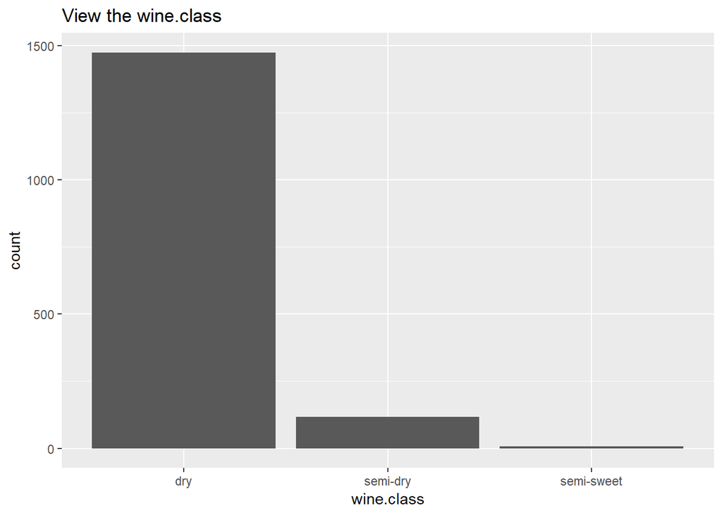

## 7.alcohol

下面我们来看看一下alcohol变量的情况 查阅资料后知道，红酒中酒精的单位一般为使用百分比来计算的，而红酒一瓶一般为750ml， 所以下面中的数字的单位应该为酒精占的百分比含量。下图的summary可以看出9.5 到11 之间的酒精含量，然后也是两边递减的关系，酒精含量浓度很高或者很低的都比较少

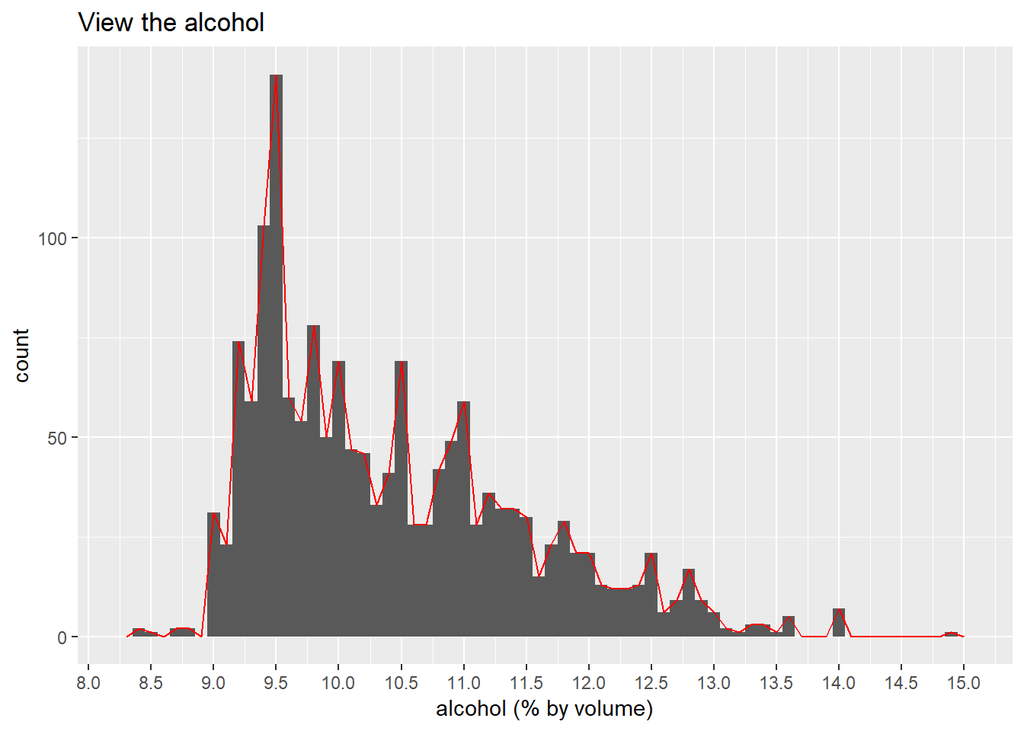

```
##    Min. 1st Qu.  Median    Mean 3rd Qu.    Max.
##    8.40    9.50   10.20   10.42   11.10   14.90
```

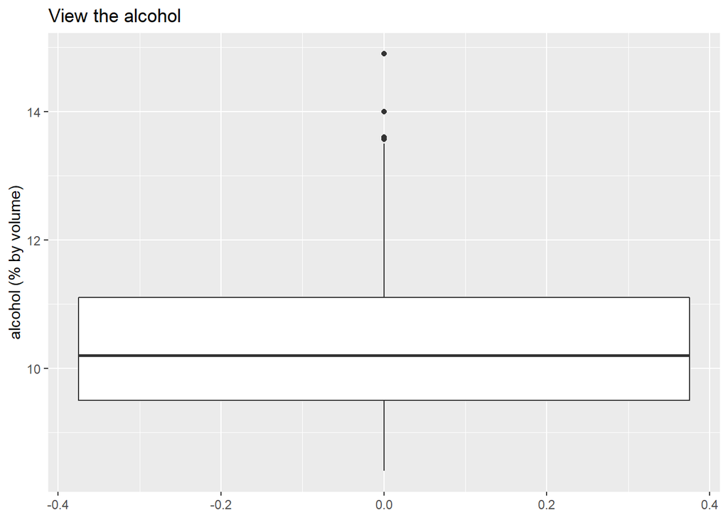

## 8.density（密度）

这个变量应该是对红酒口感影响比较大的，我们来观察一下 我们发现density之间的差值都很小，而且分布比较像正态分布， 然后他的范围一般在0.993 到 1.000之间，变化差别比较小， 暂时不知道对品质的评判影响大不大，后面多变量分析再看看

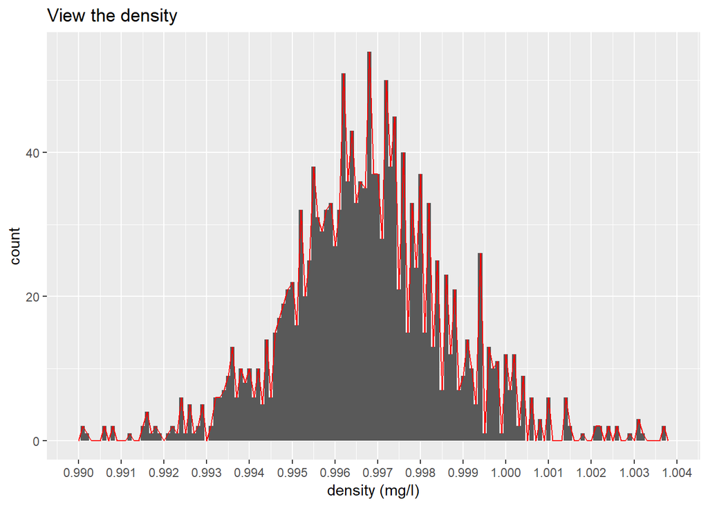

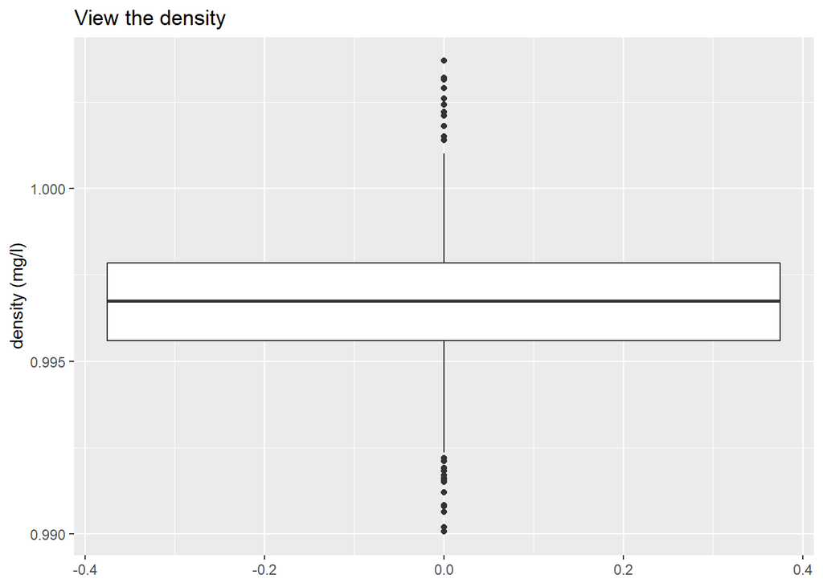

## 9.pH

然后是对pH 变量来进行分析，pH为7为中性，低于7为酸性，高于7为碱性。 我们可以看到数据集中的pH都是小于7的，所以我们喝的红酒都是酸的。

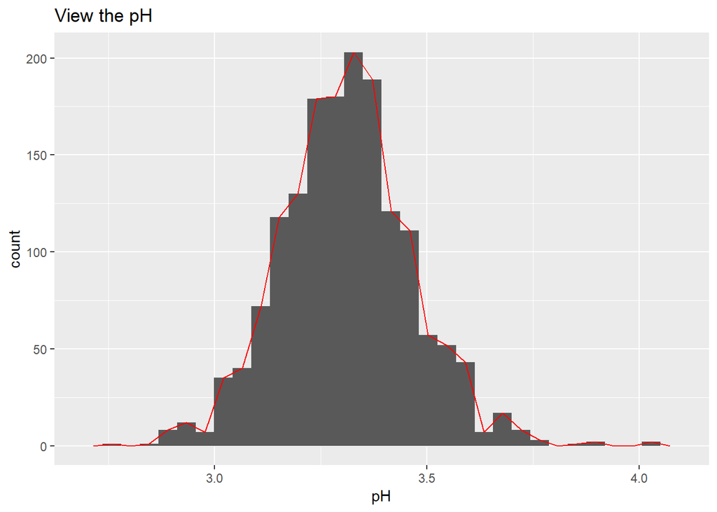

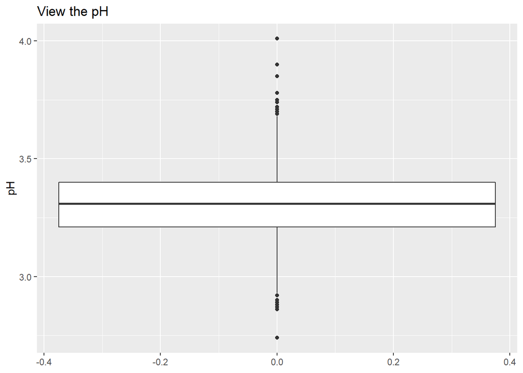

## 8.citric.acid 柠檬酸

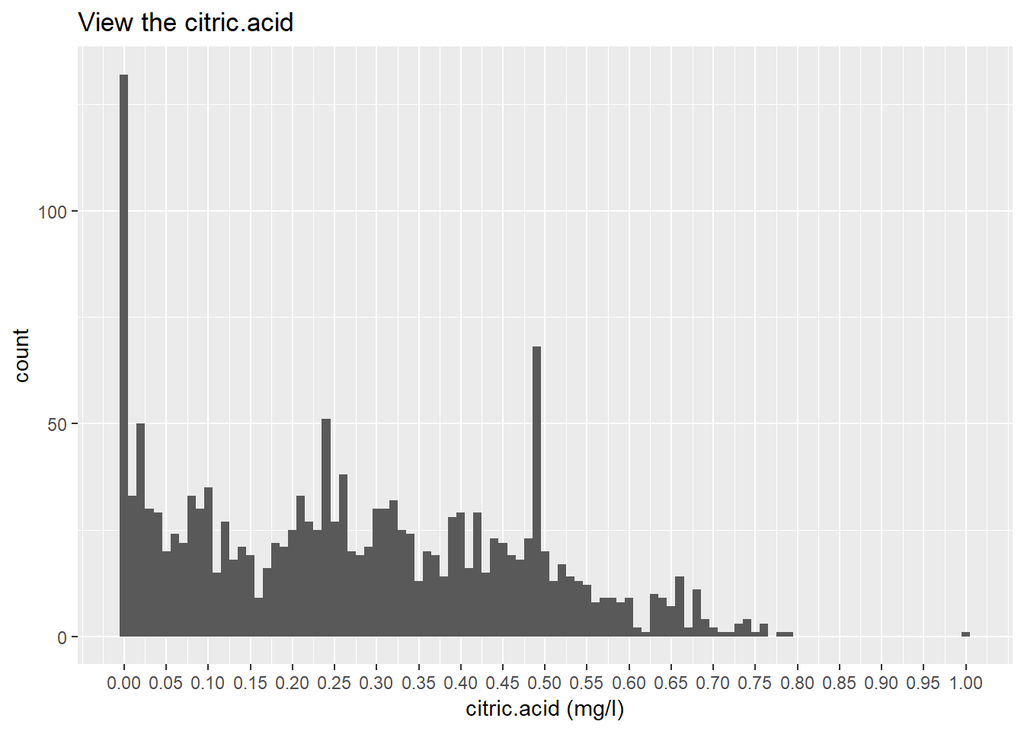

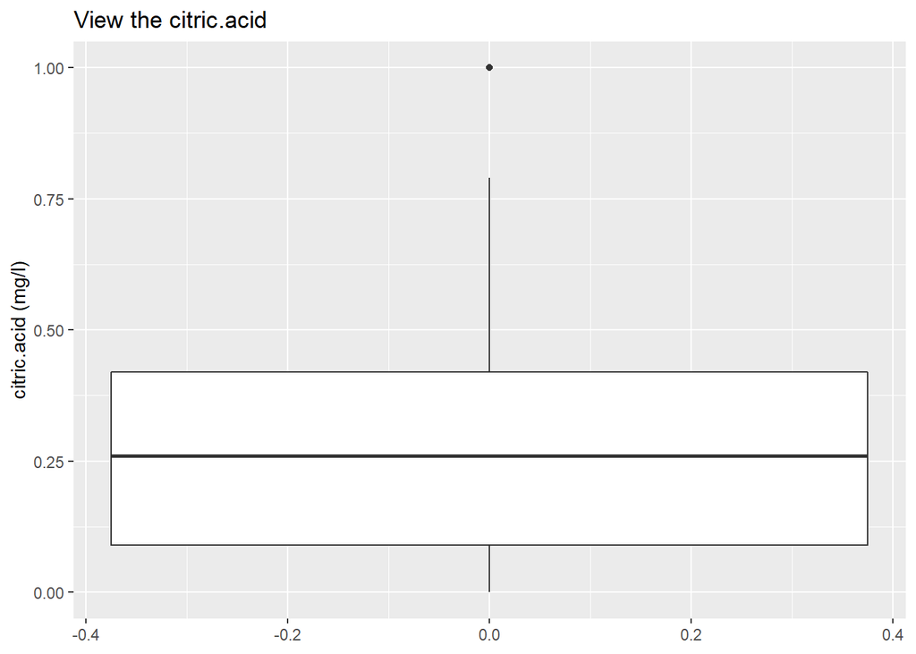

## 9.fixed.acidity 固定酸

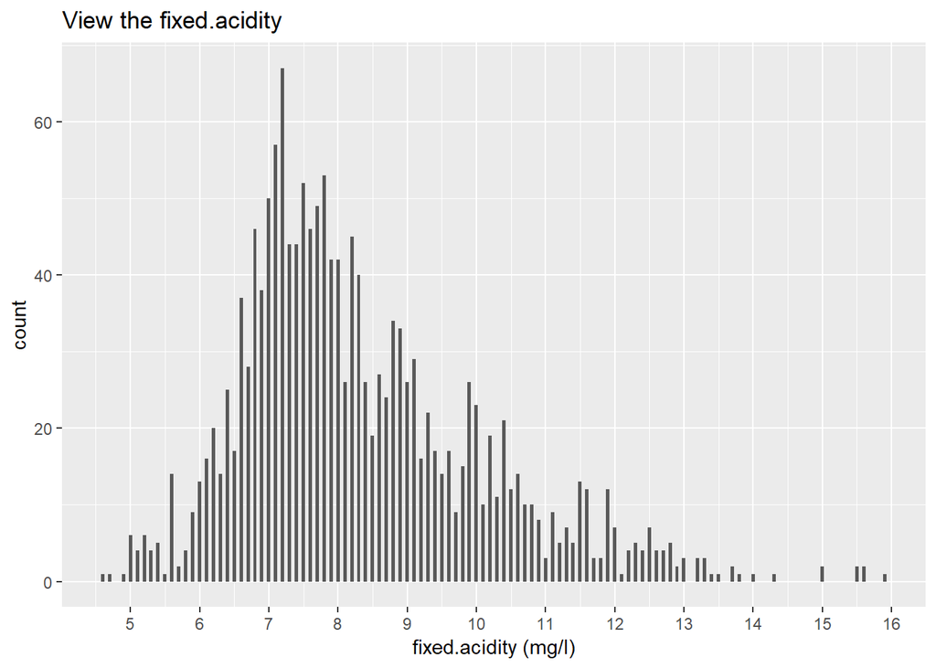

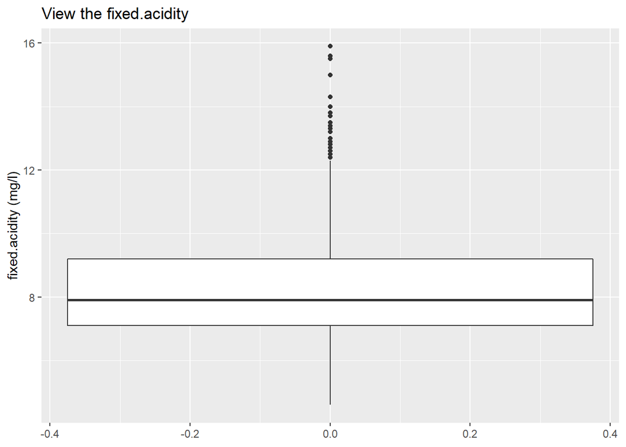

## 10.quality 品质

品质大部分都是5，6，数据集中最好的8品质和最差的3品质都很少。

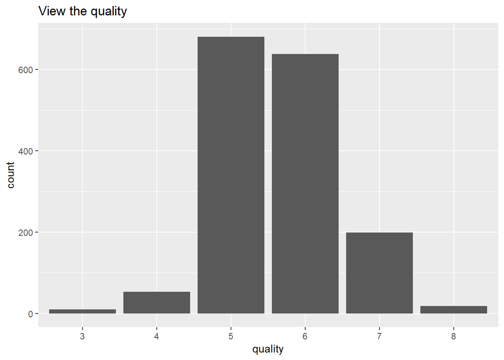

# 单变量分析

### 你的数据集结构是什么？

数据集结构情况如上可视化可见。

### 你的数据集内感兴趣的主要特性有哪些？

1.residual.sugar 残留糖 2.chlorides 氯化物 3.free.sulfur.dioxide 游离二氧化硫 4.total.sulfur.dioxide 合计二氧化硫 5.sulphates 硫酸盐 6.density 密度，浓度，稠度 7.pH 8.fixed.acidity 固定酸 9.citric.acid 柠檬酸 10.quality 品质 11.alcohol 酒精 12.quality 品质

### 你认为数据集内哪些其他特征可以帮助你探索兴趣特点？

residual.sugar 残留糖 alcohol 酒精 chlorides 氯化物 density 密度，浓度，稠度 citric.acid 柠檬酸

### 根据数据集内已有变量，你是否创建了任何新变量？

根据residual.sugar(残留糖) 的含量的不同创造出了新分类变量， wine.class，用来根据糖的含量来对葡萄酒进行划分种类。

### 在已经探究的特性中，是否存在任何异常分布？你是否对数据进行一些操作，如清洁、调整或改变数据的形式？如果是，你为什么会这样做？

单变量分析中发现有些变量的分布是存在异常分布的， 不过根据需要把X和quality改成了factor类型。暂时没有对数据进行任何处理， 具体的处理可能在后面进行双、多变量分析的时候再根据需要来进行处理。

# 双变量分析

## 绘制点图矩阵进行整体变量的概略观察

绘制点图矩阵进行整体变量的概略观察，因为X是id,为累加的情况，所以就不进行观察。 ggpair绘制的点图矩阵可以看到如下相关性比较强的几个变量的情况， 多个变量分析时候需要注意（从ggpair点阵图看出相关性）

citric.acid & fixed.acidity 0.672 强相关 citric.acid & volatile.acidity -0.552 中等程度相关 total.sulfur.dioxide & free.sulfur.dioxide 0.668 强相关 density & fixed.acidity 0.668 强相关 pH & fixed.acidity -0.683 负相关 强相关 pH & citric.acid -0.542 中等程度相关 alcohol & density -0.496 中等程度相关 quality & alcohol 0.476 中等程度相关

除了以上的，还需要探索变量的变量是： wine.class 、residual.sugar 等和quality之间的关系

## residual.sugar & quality (残留糖和品质的关系)

受下是残留糖，可以看出数据集中品质处于中间的红酒含糖量的范围比较大， 而低品质的和更高品质的红酒的含糖范围一般都比较少。 看起来好像对品质的影响关系不大。

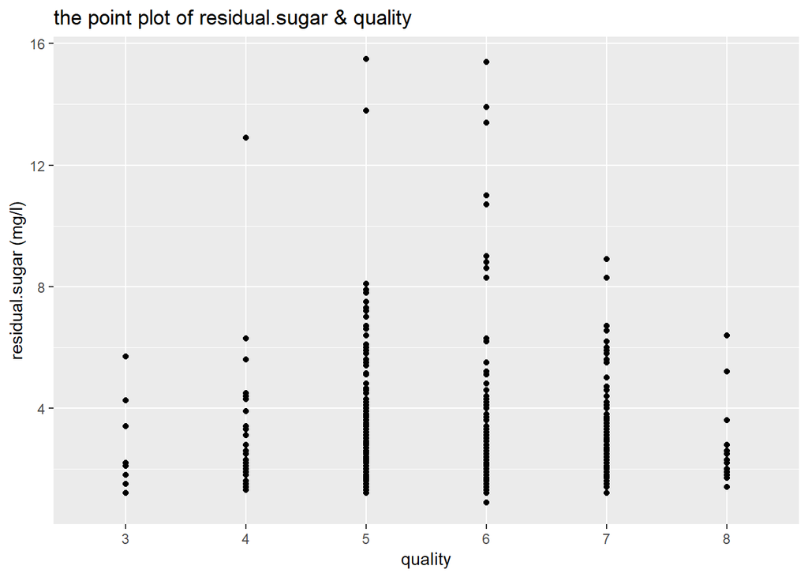

[figure not shown]

```
## wineQuantity$quality: 3
##    Min. 1st Qu.  Median    Mean 3rd Qu.    Max.
##   1.200   1.875   2.100   2.635   3.100   5.700
## --------------------------------------------------------
## wineQuantity$quality: 4
##    Min. 1st Qu.  Median    Mean 3rd Qu.    Max.
##   1.300   1.900   2.100   2.694   2.800  12.900
## --------------------------------------------------------
## wineQuantity$quality: 5
##    Min. 1st Qu.  Median    Mean 3rd Qu.    Max.
##   1.200   1.900   2.200   2.529   2.600  15.500
## --------------------------------------------------------
## wineQuantity$quality: 6
##    Min. 1st Qu.  Median    Mean 3rd Qu.    Max.
##   0.900   1.900   2.200   2.477   2.500  15.400
## --------------------------------------------------------
## wineQuantity$quality: 7
##    Min. 1st Qu.  Median    Mean 3rd Qu.    Max.
##   1.200   2.000   2.300   2.721   2.750   8.900
## --------------------------------------------------------
## wineQuantity$quality: 8
##    Min. 1st Qu.  Median    Mean 3rd Qu.    Max.
##   1.400   1.800   2.100   2.578   2.600   6.400
```

## wine.class & quality (红酒品种（按含糖量划分）和品质的关系)

而使用残留糖衍生出来的分类变量看，种类和质量的关系，更明显看出，数据集中， 人们大多喜欢品尝干型、半干型的红酒，而半甜的占很少很少的量，而甜型的 ，数据集中甚至都没有出现。

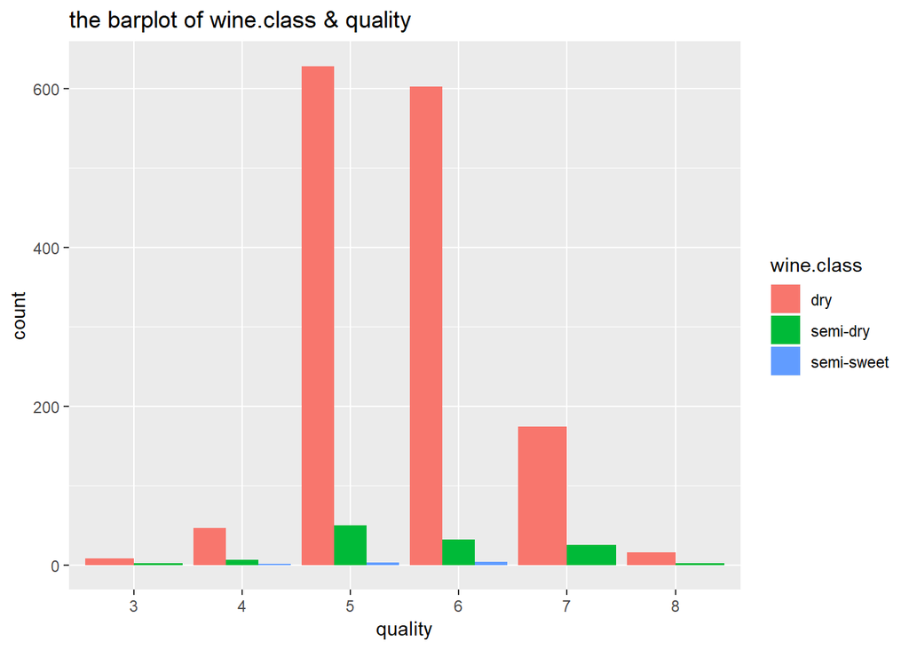

```
## wineQuantity$quality: 3
##        dry   semi-dry semi-sweet
##          8          2          0
## --------------------------------------------------------
## wineQuantity$quality: 4
##        dry   semi-dry semi-sweet
##         46          6          1
## --------------------------------------------------------
## wineQuantity$quality: 5
##        dry   semi-dry semi-sweet
##        628         50          3
## --------------------------------------------------------
## wineQuantity$quality: 6
##        dry   semi-dry semi-sweet
##        602         32          4
## --------------------------------------------------------
## wineQuantity$quality: 7
##        dry   semi-dry semi-sweet
##        174         25          0
## --------------------------------------------------------
## wineQuantity$quality: 8
##        dry   semi-dry semi-sweet
##         16          2          0
```

## residual.sugar & alcohol （残留糖和酒精含量的关系）

那我们进而看看残留糖的含量是否和红酒的发酵是否完全有关， 可以看到残留糖主要都集中在残留糖为4之前横跨酒精含量9~12之间各种酒精含量， 那么推测可能残留糖和酒精含量之间关系不大， 也就是说残留糖不一定和红酒是否完全发酵有关。

[figure not shown]

## alcohol & quality

整体看着点图的移动，因为是中等程度正相关的相互关系，所以可以看到， 随着酒精含量的上升，品质渐渐的上升. 不过酒精含量整体是小于12的，主要集中在品质5~6之间

```
## wineQuantity$quality: 3
##    Min. 1st Qu.  Median    Mean 3rd Qu.    Max.
##   8.400   9.725   9.925   9.955  10.575  11.000
## --------------------------------------------------------
## wineQuantity$quality: 4
##    Min. 1st Qu.  Median    Mean 3rd Qu.    Max.
##    9.00    9.60   10.00   10.27   11.00   13.10
## --------------------------------------------------------
## wineQuantity$quality: 5
##    Min. 1st Qu.  Median    Mean 3rd Qu.    Max.
##     8.5     9.4     9.7     9.9    10.2    14.9
## --------------------------------------------------------
## wineQuantity$quality: 6
##    Min. 1st Qu.  Median    Mean 3rd Qu.    Max.
##    8.40    9.80   10.50   10.63   11.30   14.00
## --------------------------------------------------------
## wineQuantity$quality: 7
##    Min. 1st Qu.  Median    Mean 3rd Qu.    Max.
##    9.20   10.80   11.50   11.47   12.10   14.00
## --------------------------------------------------------
## wineQuantity$quality: 8
##    Min. 1st Qu.  Median    Mean 3rd Qu.    Max.
##    9.80   11.32   12.15   12.09   12.88   14.00
```

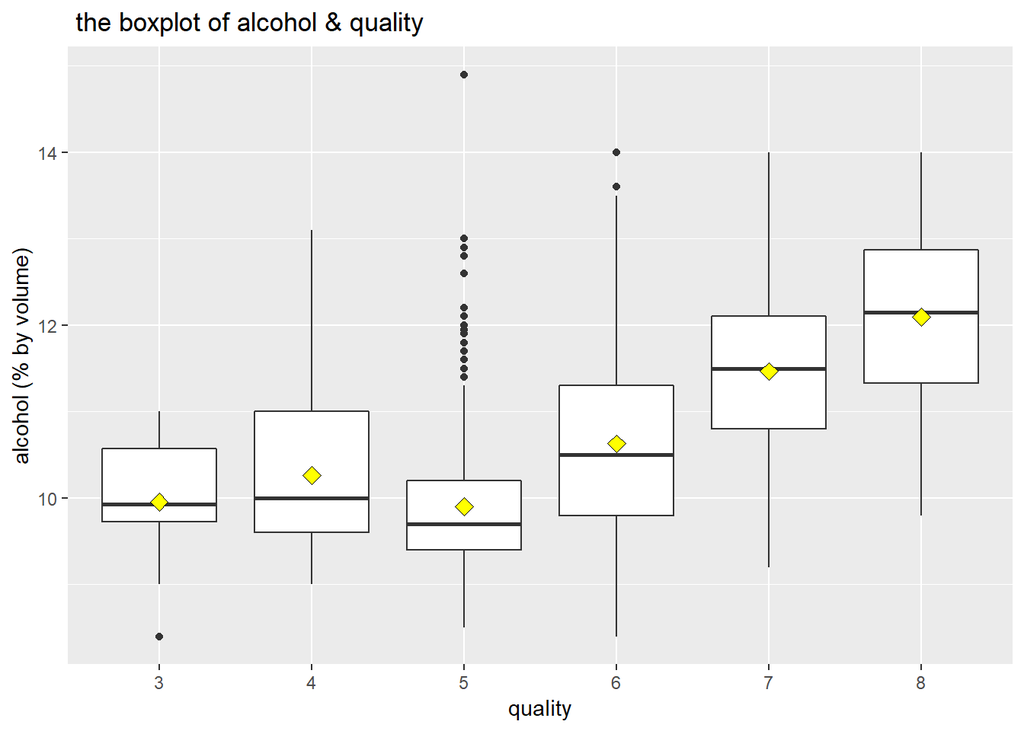

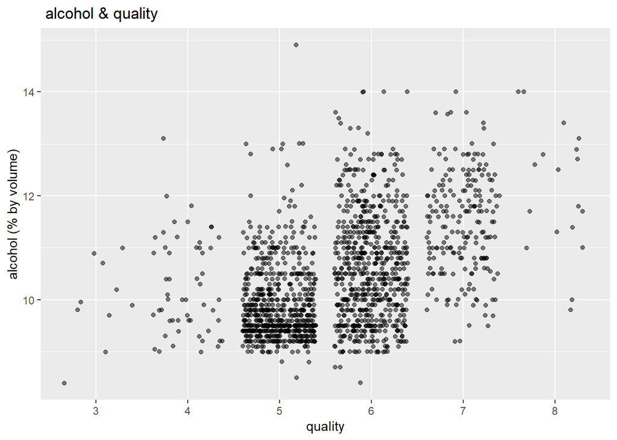

### 查看不同 quality(品质) 下alcohol(酒精)的均值和中位数的变化情况

由单变量分析时候的ggpair 概略查看得知，quality & alcohol 0.476 中等程度相关 总体看来是同时增大而增大的，但是品质为5的却又比品质为3、4的酒精含量更底

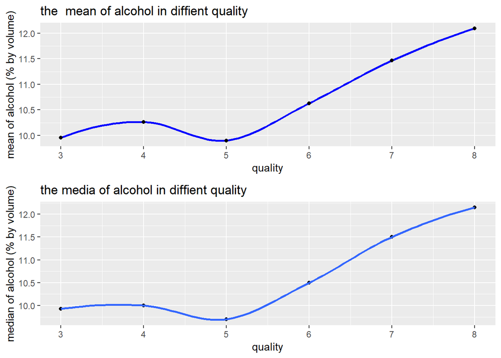

## density & quality

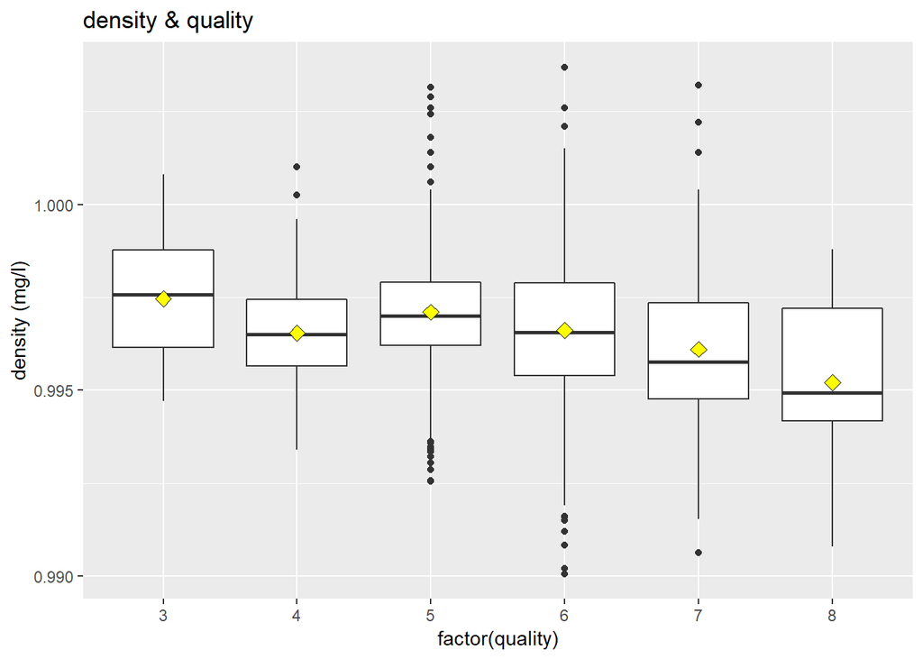

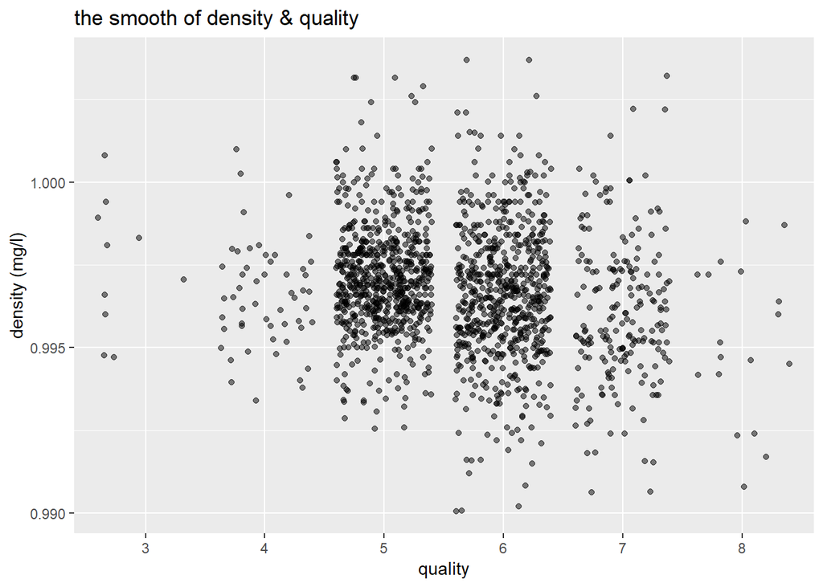

```
## wineQuantity$quality: 3
##    Min. 1st Qu.  Median    Mean 3rd Qu.    Max.
##  0.9947  0.9961  0.9976  0.9975  0.9988  1.0008
## --------------------------------------------------------
## wineQuantity$quality: 4
##    Min. 1st Qu.  Median    Mean 3rd Qu.    Max.
##  0.9934  0.9957  0.9965  0.9965  0.9974  1.0010
## --------------------------------------------------------
## wineQuantity$quality: 5
##    Min. 1st Qu.  Median    Mean 3rd Qu.    Max.
##  0.9926  0.9962  0.9970  0.9971  0.9979  1.0031
## --------------------------------------------------------
## wineQuantity$quality: 6
##    Min. 1st Qu.  Median    Mean 3rd Qu.    Max.
##  0.9901  0.9954  0.9966  0.9966  0.9979  1.0037
## --------------------------------------------------------
## wineQuantity$quality: 7
##    Min. 1st Qu.  Median    Mean 3rd Qu.    Max.
##  0.9906  0.9948  0.9958  0.9961  0.9974  1.0032
## --------------------------------------------------------
## wineQuantity$quality: 8
##    Min. 1st Qu.  Median    Mean 3rd Qu.    Max.
##  0.9908  0.9942  0.9949  0.9952  0.9972  0.9988
```